# Kydland & Prescott (1982): Real Business Cycles

David Evans

2026-05-28

# Introduction

## From Micro to Macro

### Where We’ve Been

- **McCall (1970)**: an unemployed worker searches for a job
  - solve for a reservation wage
- **Rust (1987)**: a bus superintendent decides when to replace engines
  - solve for replacement probabilities
- Both models feature a **single agent** making decisions in a **micro** environment
- Today we scale up: a **representative agent** in a **macroeconomy**

### Kydland & Prescott (1982)

- **“Time to Build and Aggregate Fluctuations”**
  - *Econometrica* and 10000+ citations
- Won the **2004 Nobel Prize** in Economics
- Key question: Can a **competitive equilibrium** model with **technology shocks** explain business cycles?

**The RBC Revolution**

Before KP (1982), business cycles were thought to require market failures (sticky prices, coordination failures). KP showed that a **perfectly competitive** economy hit by productivity shocks could generate realistic fluctuations.

### The Big Idea

- Business cycles as the **optimal response** of a competitive economy to random productivity shocks
- No market failures, no government intervention needed to explain fluctuations
- The core model: a **stochastic neoclassical growth model**
  - Households save and consume optimally
  - Firms produce using capital and labor
  - Productivity fluctuates randomly

**Connection to Previous Lectures**

The RBC model combines: **dynamic programming** (McCall, Rust), **Markov chains** (productivity shocks), and **linear algebra** (matrix operations for expectations).

### A New Computational Challenge

- In McCall and Rust, the state space was **discrete** (wage offers, mileage bins)
- We stored the value function as a **vector** and looked up values directly
- In the RBC model, capital $k$ is **continuous** — we can’t just index into a vector!
- We’ll introduce **linear interpolation**
  - a tool for evaluating functions at arbitrary points, not just grid points
- This unlocks a whole class of models with **continuous state spaces**

## Roadmap

### What We’ll Cover

1. **The Model** — households, firms, competitive equilibrium, and the social planner’s problem
2. **Calibration** — matching long-run moments and the productivity process
3. **Linear Interpolation** — a new tool for continuous state spaces
4. **Solving the Model** — value function iteration with interpolation
5. **Simulation** — generating artificial business cycles with `DataFrames`
6. **Linearized Solution** — differentiating the Euler equation for a fast, analytical policy rule

# The Stochastic Growth Model

## The Household

### The Household’s Problem

- A representative household lives forever and maximizes:

$$\max_{\{c_t, k_{t+1}\}} \; \mathbb{E}_0 \sum_{t=0}^{\infty} \beta^t \log(c_t)$$

- $c_t$: consumption in period $t$
- $\beta \in (0,1)$: discount factor
- $\log(c_t)$: log utility
  - more consumption is better, but with **diminishing returns**

### Income and Ownership

- The household **owns capital** $k_t$ and supplies **one unit of labor** each period (inelastically)
- It earns two types of income:
1. **Rental income**: $r_t k_t$ from renting capital to firms
2. **Wage income**: $w_t$ from supplying labor
- The household takes prices $(r_t, w_t)$ as given: it is a **price taker** in competitive markets

### The Budget Constraint

- Each period, the household faces the budget constraint:

$$c_t + k_{t+1} = w_t + r_t \, k_t + (1 - \delta) \, k_t$$

- **Left side**: uses of funds
  - consumption today + capital carried into tomorrow
- **Right side**: sources of funds
  - wages + capital income + undepreciated capital
- The household chooses $c_t$ and $k_{t+1}$ to maximize lifetime utility subject to this constraint

**Simplification**

We fix labor supply at $\ell_t = 1$ (inelastic). The full KP (1982) model includes labor-leisure choice and time-to-build for investment, which generate additional dynamics. The core insights carry through without these.

## The Firm

### The Firm’s Problem

- A representative firm produces output using capital and labor:

$$y_t = z_t \, k_t^\alpha \, \ell_t^{1-\alpha}$$

- $z_t$: **total factor productivity** (TFP): the random shock driving business cycles
- $\alpha \in (0,1)$: capital’s share of output (typically $\approx 1/3$)
- **Constant returns to scale** (CRS): doubling both inputs doubles output

### Profit Maximization

- The firm rents capital at rate $r_t$ and hires labor at wage $w_t$:

$$\pi_t = z_t \, k_t^\alpha \, \ell_t^{1-\alpha} - r_t \, k_t - w_t \, \ell_t$$

- First-order conditions (set marginal product = factor price):

$$r_t = \alpha \, z_t \, k_t^{\alpha - 1} \, \ell_t^{1-\alpha} \qquad\qquad w_t = (1-\alpha) \, z_t \, k_t^{\alpha} \, \ell_t^{-\alpha}$$

**Zero Profits**

With CRS, paying each factor its marginal product **exactly exhausts output**: $r_t k_t + w_t \ell_t = y_t$. The firm earns zero profits in equilibrium

### Factor Prices in Equilibrium

- Since the household supplies $\ell_t = 1$ unit of labor, the factor prices simplify to:

$$r_t = \alpha \, z_t \, k_t^{\alpha - 1} \qquad\qquad w_t = (1-\alpha) \, z_t \, k_t^{\alpha}$$

- The rental rate **falls** with capital (diminishing returns)
- The wage **rises** with capital (more capital per worker $\rightarrow$ higher productivity)
- Both move with $z_t$: when productivity is high, **all** factor prices rise

## Technology Shocks

### The Driving Force

- Productivity follows an **AR(1) process** in logs:

$$\log z_{t+1} = \rho \, \log z_t + \sigma_\varepsilon \, \varepsilon_{t+1}, \qquad \varepsilon_{t+1} \sim N(0, 1)$$

- $\rho \in (0,1)$: persistence of technology shocks (typically 0.9–0.95)
- $\sigma_\varepsilon$: volatility of technology innovations
- High $\rho$ means a good shock today predicts good productivity tomorrow: **persistence** drives business cycle dynamics

**Connecting to Markov Chains**

We’ll **discretize** this continuous AR(1) process into a finite-state Markov chain. This lets us use our Markov chain tools!

### Discretizing the AR(1): Rouwenhorst Method

- We approximate the continuous AR(1) with an $N$-state Markov chain
- The **Rouwenhorst (1995)** method:
  1. Create an evenly spaced grid for $\log z$ spanning $\pm \sqrt{N-1} \cdot \sigma_z$
  2. Build the transition matrix **recursively**

**Why Rouwenhorst?**

Rouwenhorst is simpler to implement than Tauchen (1986) (an alternative method) and performs **better for highly persistent** processes ($\rho$ close to 1): exactly the case in RBC models.

### The `rouwenhorst` Function

```julia
function rouwenhorst(N, ρ, σ_ε)
    σ_z = σ_ε / sqrt(1 - ρ^2)                     # unconditional std dev
    p = (1 + ρ) / 2                                 # persistence parameter
    P = [p 1-p; 1-p p]                             # base case: N = 2
    for n in 3:N                                    # recursively expand
        z = zeros(n - 1)
        P = p     * [P z; z' 0] + (1-p) * [z P; 0 z'] +
            (1-p) * [z' 0; P z] + p     * [0 z'; z P]
        P[2:end-1, :] ./= 2                        # normalize interior rows
    end
    z_grid = collect(LinRange(-sqrt(N-1) * σ_z,     # evenly spaced grid
                               sqrt(N-1) * σ_z, N))
    return z_grid, P
end
```

```
rouwenhorst (generic function with 1 method)
```

### Testing the Rouwenhorst Approximation

```julia
log_z_grid, P_z = rouwenhorst(7, 0.90, 0.02)
z_grid = exp.(log_z_grid)                           # convert to levels
round.(z_grid, digits=4)
```

```
7-element Vector{Float64}:
 0.8937
 0.9278
 0.9632
 1.0
 1.0382
 1.0778
 1.1189
```

```julia
round.(P_z, digits=3)
```

```
7×7 Matrix{Float64}:
 0.735  0.232  0.031  0.002  0.0    0.0    0.0
 0.039  0.745  0.195  0.02   0.001  0.0    0.0
 0.002  0.078  0.751  0.156  0.012  0.0    0.0
 0.0    0.006  0.117  0.753  0.117  0.006  0.0
 0.0    0.0    0.012  0.156  0.751  0.078  0.002
 0.0    0.0    0.001  0.02   0.195  0.745  0.039
 0.0    0.0    0.0    0.002  0.031  0.232  0.735
```

- High diagonal values: the economy tends to stay near its current productivity level

### Visualizing the Transition Matrix

```julia
using Plots
heatmap(P_z, xlabel="Next State", ylabel="Current State",
        title="Transition Matrix for Productivity", color=:viridis, yflip=true)
```

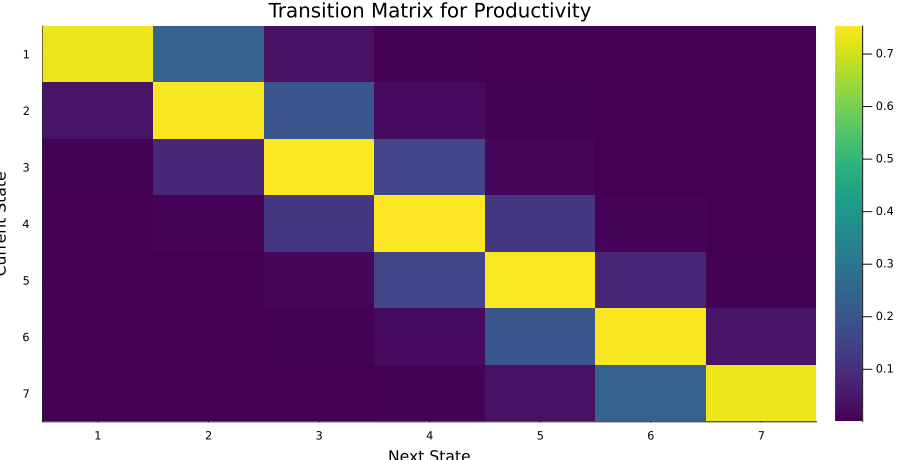

## Competitive Equilibrium

### Definition

**Competitive Equilibrium**

A **competitive equilibrium** is a sequence of prices $\{r_t, w_t\}_{t=0}^{\infty}$ and allocations $\{c_t, k_{t+1}\}_{t=0}^{\infty}$ such that:

1. **Household optimizes**: given prices, the household maximizes expected lifetime utility subject to its budget constraint
2. **Firm optimizes**: given prices, the firm’s factor demands satisfy $r_t = \text{MPK}$ and $w_t = \text{MPL}$
3. **Markets clear**: the labor market clears ($\ell_t = 1$) and the goods market clears ($c_t + k_{t+1} - (1-\delta)k_t = y_t$)

### From Budget Constraint to Resource Constraint

- Substituting the zero-profit factor prices into the household’s budget constraint:

$$c_t + k_{t+1} = \underbrace{(1-\alpha) \, z_t \, k_t^\alpha}_{w_t} + \underbrace{\alpha \, z_t \, k_t^{\alpha-1}}_{r_t} \cdot k_t + (1-\delta) \, k_t$$

$$c_t + k_{t+1} = z_t \, k_t^\alpha + (1-\delta) \, k_t$$

- The budget constraint **collapses to the aggregate resource constraint**!
- Wages + rental income = total output (zero profits under CRS)

### Why This Matters

- In the competitive equilibrium, we would need to track:
  - Household optimization (Euler equation)
  - Firm optimization (factor prices)
  - Market clearing conditions
- That’s a lot of moving parts! Is there a shortcut?

**Yes! The First Welfare Theorem!**

## The First Welfare Theorem

### From Equilibrium to Planning

- The **First Welfare Theorem** states: under standard conditions (complete markets, no externalities, price-taking behavior), a competitive equilibrium allocation is **Pareto optimal**
- A Pareto optimal allocation is exactly what a **benevolent social planner** would choose

**The Shortcut**

The CE allocation = the planner’s solution. So instead of tracking prices and market clearing, we can solve the **much simpler planner’s problem** and recover the competitive equilibrium allocations directly.

- To find equilibrium **prices**, we can always back them out: $r_t = \alpha z_t k_t^{\alpha-1}$ and $w_t = (1-\alpha) z_t k_t^\alpha$

# The Social Planner’s Problem

## The Sequential Problem

- Given initial conditions $(k_0, z_0)$, the planner chooses **entire sequences** of consumption and capital to maximize expected lifetime utility:

$$\max_{\{c_t,\, k_{t+1}\}_{t=0}^{\infty}} \; \mathbb{E}_0 \sum_{t=0}^{\infty} \beta^t \log(c_t)$$

subject to, for every $t \geq 0$,
$$c_t + k_{t+1} = z_t \, k_t^\alpha + (1-\delta) \, k_t, \qquad c_t \geq 0, \quad k_{t+1} \geq 0$$

- Productivity follows the **finite-state Markov chain** from Rouwenhorst:
  - let $\bar z_1, \ldots, \bar z_S$ denote the $S$ possible productivity values
  - let $s_t \in \{1, \ldots, S\}$ be the index, so $z_t = \bar z_{s_t}$
  - transition matrix $P_{s, s'} = \Pr(s_{t+1} = s' \mid s_t = s)$
- This is an **infinite-dimensional** optimization problem
  - one choice per period, forever, across every possible realization of $\{s_t\}$
- Bellman equations help us break this giant problem into something manageable!

### Splitting: Today vs. the Future

- Pull the $t = 0$ term out of the sum and factor $\beta$ from the rest:

$$\mathbb{E}_0 \sum_{t=0}^{\infty} \beta^t \log(c_t) = \log(c_0) + \beta \, \mathbb{E}_0 \sum_{t=1}^{\infty} \beta^{t-1} \log(c_t)$$

- The planner’s problem becomes a **choice today** plus a **continuation problem** starting tomorrow:

$$\max_{c_0,\, k_1} \left\{ \log(c_0) + \beta \, \mathbb{E}_0 \left[\; \max_{\{c_t,\, k_{t+1}\}_{t=1}^\infty} \sum_{t=1}^\infty \beta^{t-1} \log(c_t) \;\right] \right\}$$

- The inner problem has the **same form** as the original, just starting from $(k_1, s_1)$ instead of $(k_0, s_0)$
  - the **Markov property** is key: tomorrow’s distribution depends only on $s_1$, not the whole history $\{s_0, s_1\}$
- Define $V(k, s)$ as the value of the planner’s problem starting with capital $k$ when productivity is $\bar z_s$
  - then the inner max equals $V(k_1, s_1)$

### The Bellman Equation

- Substituting $V(k_1, s_1)$ for the continuation problem and dropping time-0 subscripts gives a **recursive** problem in just two variables:
- State variables: $(k, s)$ — current capital and productivity index
- Control variable: $k'$ (which pins down $c = \bar z_s \, k^\alpha + (1-\delta)k - k'$)

$$V(k, s) = \max_{k'} \left\{ \log(c) + \beta \, \mathbb{E}\left[V(k', s') \mid s\right] \right\}$$

where $c = \bar z_s \, k^\alpha + (1-\delta) k - k' > 0$

- The conditional expectation is a **sum over the Markov chain**:
  $$\mathbb{E}\left[V(k', s') \mid s\right] = \sum_{s' = 1}^{S} P_{s, s'} \, V(k', s')$$

## The Deterministic Steady State

### What Happens Without Shocks?

- Before solving the full stochastic model, consider: what if productivity were **constant** at $z = 1$?
- In the long run, capital settles at a **steady state** $k_{ss}$ where $k_{t+1} = k_t = k_{ss}$
- At the steady state, the household **consumes all output net of depreciation**:
  - Investment exactly replaces worn-out capital: $i_{ss} = \delta \, k_{ss}$
  - Consumption: $c_{ss} = k_{ss}^\alpha - \delta \, k_{ss}$
- Understanding the steady state helps us in **three** ways:
  1. It tells us **where capital should be** on average
  2. It guides our **grid construction** (center the grid around $k_{ss}$)
  3. It provides a **starting point** for simulation

### Deriving $k_{ss}$: A Perturbation Argument

- Suppose the planner is at the steady state and considers saving **one extra unit** of capital today
- **Cost**: consuming one less unit today reduces utility by $\frac{1}{c_{ss}}$
- **Benefit**: that extra unit of capital produces $\alpha \, k_{ss}^{\alpha - 1}$ extra output tomorrow, plus $(1-\delta)$ undepreciated capital comes back
  - valued at $\frac{1}{c_{ss}}$ and discounted by $\beta$

$$\text{Benefit} = \beta \cdot \frac{\alpha \, k_{ss}^{\alpha - 1} + 1 - \delta}{c_{ss}}$$

### The Steady State Condition

- At the optimum, the planner **cannot improve** by saving more or less: cost = benefit

$$\frac{1}{c_{ss}} = \beta \cdot \frac{\alpha \, k_{ss}^{\alpha - 1} + 1 - \delta}{c_{ss}}$$

- The $\frac{1}{c_{ss}}$ terms cancel, leaving:

$$1 = \beta \left( \alpha \, k_{ss}^{\alpha - 1} + 1 - \delta \right)$$

- Solving for $k_{ss}$:

$$\boxed{k_{ss} = \left(\frac{\alpha \beta}{1 - \beta(1-\delta)}\right)^{\frac{1}{1-\alpha}}}$$

### Interpreting the Steady State

- The term $\alpha \, k_{ss}^{\alpha - 1}$ is the **marginal product of capital**
  - the steady-state rental rate $r_{ss}$
- Our condition says $\beta(r_{ss} + 1 - \delta) = 1$, or:

$$r_{ss} = \frac{1}{\beta} - (1-\delta)$$

- The **more patient** the household ($\beta$ closer to 1), the **lower** the equilibrium interest rate
  - patient agents save more, driving down returns

**The Logic of the Steady State**

The planner keeps accumulating capital until the **net return** ($r_{ss} - \delta$) falls to match the household’s **rate of impatience** ($1/\beta - 1$). At that point, saving one more unit costs exactly as much as it benefits

## Setup in Julia

### Loading Packages

```julia
using Plots
using LinearAlgebra
using Statistics
using Distributions
using Random
using Optim
using Interpolations
using DataFrames
```

### The `RBCModel` Struct

- A `mutable struct` holds the model parameters and the objects we’ll compute from them:

```julia
@kwdef mutable struct RBCModel
    β::Float64 = 0.96                           # discount factor
    α::Float64 = 0.33                           # capital share
    δ::Float64 = 0.08                           # depreciation rate
    ρ::Float64 = 0.90                           # persistence of TFP
    σ_ε::Float64 = 0.02                         # std dev of TFP innovation
    N_z::Int = 7                                # number of productivity states
    N_k::Int = 200                              # number of capital grid points


    z_grid::Vector{Float64} = Float64[]         # filled by setup!
    P_z::Matrix{Float64} = zeros(0,0)           # filled by setup!
    k_grid::Vector{Float64} = Float64[]         # filled by setup!
end
```

```
RBCModel
```

- The economic parameters ($\beta, \alpha, \delta, \rho, \sigma_\varepsilon$) have sensible defaults
- The grids and transition matrix start empty
  - we fill them with a `setup!` function

### The `setup!` Function

- Compute everything the model needs from the primitives:

```julia
function setup!(m::RBCModel)
    (; α, β, δ, ρ, σ_ε, N_z, N_k) = m
    # Discretize productivity
    log_z, P = rouwenhorst(N_z, ρ, σ_ε)
    m.z_grid = exp.(log_z)
    m.P_z = P
    # Capital grid centered on steady state
    k_ss = (α * β / (1 - β*(1-δ)))^(1/(1-α))
    m.k_grid = collect(LinRange(0.2k_ss, 1.8k_ss, N_k))
    return m
end
```

```
setup! (generic function with 1 method)
```

- `setup!` **mutates** the struct (note the `!` convention)
  - it fills in `z_grid`, `P_z`, and `k_grid`
- Calling `setup!` again after changing a parameter rebuilds everything consistently

### Creating and Inspecting the Model

```julia
m = setup!(RBCModel())                               # create with defaults and set up
```

```
RBCModel(0.96, 0.33, 0.08, 0.9, 0.02, 7, 200, [0.8936953824472262, 0.927811339397771, 0.9632296400120643, 1.0, 1.0381740329206182, 1.0778053226306605, 1.118949498498781], [0.7350918906249998 0.23213428125000016 … 1.781250000000008e-6 1.5625000000000085e-8; 0.03868904687500002 0.74527321875 … 2.82187…
```

```julia
println("z_grid: ", round.(m.z_grid, digits=4))
println("k_grid: [$(round(m.k_grid[1], digits=3)), ..., $(round(m.k_grid[end], digits=3))]")
println("N_k = $(m.N_k) grid points")
```

```
z_grid: [0.8937, 0.9278, 0.9632, 1.0, 1.0382, 1.0778, 1.1189]
k_grid: [0.887, ..., 7.981]
N_k = 200 grid points
```

### The Steady State

- A helper to compute steady-state values from the model parameters:

```julia
function steady_state(m::RBCModel)
    (; α, β, δ) = m
    k_ss = (α * β / (1 - β*(1-δ)))^(1/(1-α))
    y_ss = k_ss^α
    c_ss = y_ss - δ * k_ss
    i_ss = δ * k_ss
    r_ss = α * k_ss^(α-1)
    return (k=k_ss, y=y_ss, c=c_ss, i=i_ss, r=r_ss)
end
```

```
steady_state (generic function with 1 method)
```

```julia
ss = steady_state(m)
println("k_ss = $(round(ss.k, digits=3)),  y_ss = $(round(ss.y, digits=3)),  c_ss = $(round(ss.c, digits=3)),  r_ss = $(round(ss.r, digits=3))")
```

```
k_ss = 4.434,  y_ss = 1.635,  c_ss = 1.28,  r_ss = 0.122
```

# Linear Interpolation

## Why We Need Interpolation

### The Problem

- In McCall and Rust, the state space was **discrete**
  - we stored $V$ as a vector and looked up values by index
- In the RBC model, capital $k$ is **continuous**
- We store $V$ on a grid: $V(k_1, s), V(k_2, s), \ldots, V(k_N, s)$
- But when we optimize, the optimal $k'$ will **not** land on a grid point!
- We need to evaluate $V(k', s)$ for **any** $k'$, not just grid points
- **Solution**: **interpolation**
  - use known grid values to approximate $V$ at off-grid points

### Visual Intuition

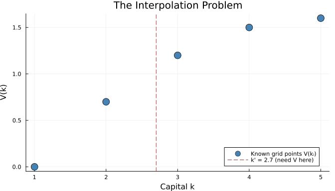

- We know $V$ at the blue dots
  - but we need $V(2.7)$!

## How Linear Interpolation Works

### The Idea

- Given two adjacent grid points $k_i$ and $k_{i+1}$ with known values $V_i$ and $V_{i+1}$:

$$V(k') \approx V_i + \frac{k' - k_i}{k_{i+1} - k_i} \cdot (V_{i+1} - V_i)$$

- Using the **interpolation weight** $w = \frac{k' - k_i}{k_{i+1} - k_i}$:

$$V(k') \approx (1 - w) \cdot V_i + w \cdot V_{i+1}$$

**Intuition**

Linear interpolation draws a **straight line** between adjacent known points and reads off the value at $k'$. The weight $w$ measures how far $k'$ is from $k_i$ toward $k_{i+1}$.

### Step by Step

1. **Find the interval**: locate $i$ such that $k_i \leq k' \leq k_{i+1}$
2. **Compute the weight**: $w = \frac{k' - k_i}{k_{i+1} - k_i} \in [0, 1]$
3. **Interpolate**: $\hat{V} = (1-w) V_i + w V_{i+1}$
- If $w = 0$: $k'$ is exactly at $k_i$ → $\hat{V} = V_i$
- If $w = 1$: $k'$ is exactly at $k_{i+1}$ → $\hat{V} = V_{i+1}$
- If $w = 0.5$: $k'$ is midway → $\hat{V} = \frac{V_i + V_{i+1}}{2}$

### `Interpolations.jl`

- Julia’s `Interpolations.jl` package does all of this for us with clean **call syntax**:

```julia
# Known grid points
k_demo = [1.0, 2.0, 3.0, 4.0, 5.0]
V_demo = [0.0, 0.7, 1.2, 1.5, 1.6]

V_itp = linear_interpolation(k_demo, V_demo)       # build interpolation object
```

```
5-element extrapolate(interpolate((::Vector{Float64},), ::Vector{Float64}, Gridded(Linear())), Throw()) with element type Float64:
 0.0
 0.7
 1.2
 1.5
 1.6
```

- Now `V_itp` behaves like a **function** — just call it with any $k'$:

```julia
V_itp(2.0)         # exact grid point → 0.7
```

```
0.7
```

```julia
V_itp(2.5)         # midpoint → (0.7 + 1.2)/2 = 0.95
```

```
0.95
```

```julia
V_itp(2.7)         # arbitrary point → 0.3×0.7 + 0.7×1.2 = 1.05
```

```
1.05
```

**Call Syntax**

`linear_interpolation(xs, ys)` returns a callable object. Writing `V_itp(k')` is just like calling a function — clean, readable, and exactly what we need inside an optimizer.

### Visualizing the Interpolation

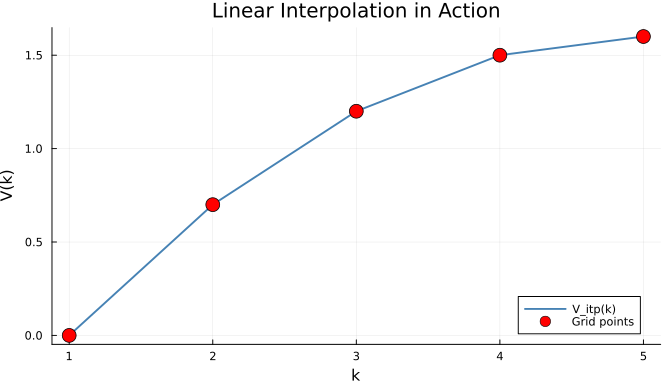

```julia
k_fine = LinRange(1.0, 5.0, 200)

plot(k_fine, V_itp.(k_fine), linewidth=2, color=:steelblue,
     label="V_itp(k)", legend=:bottomright, size=(700, 400))
scatter!(k_demo, V_demo, markersize=8, color=:red, label="Grid points")
xlabel!("k")
ylabel!("V(k)")
title!("Linear Interpolation in Action")
```

- The interpolation connects the dots with **straight line segments**
- Note the **broadcasting**: `V_itp.(k_fine)` evaluates the interpolant at every point in the vector

### Accuracy vs. Grid Size

- With more grid points, the piecewise-linear approximation better captures curvature:

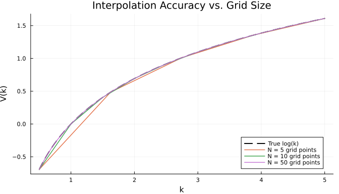

**Rule of Thumb**

For smooth economic functions, 100–500 grid points typically give excellent accuracy with linear interpolation.

# Solving the RBC Model

## The Planning Problem

### Recall: The Bellman Equation

$$V(k, s) = \max_{k'} \left\{ \log(c) + \beta \, \mathbb{E}\big[V(k', s') \mid s\big] \right\}, \qquad c = \bar z_s \, k^\alpha + (1-\delta) k - k'$$

- An **infinite-horizon, stochastic, recursive** problem — it looks intimidating
- But at its heart is a **simple one-period trade-off**: consume now vs. save for later

**The plan**

Boil this down to a problem you can solve in a few lines of Julia, then **iterate** it to recover $V$.

### A Simple Problem

- Strip away the complexity: a planner has **resources** $R$ to split between consumption $c$ and savings $k'$:

$$c + k' = R$$

- It values consumption today, $\log(c)$, and future capital, $\beta\, v^f(k')$:

$$\max_{k'} \;\; \log(\underbrace{R - k'}_{=\,c}) \;+\; \beta\, v^f(k')$$

- $v^f(k')$ is the (**known**) value of having capital $k'$ into the future
  - we’ll have to find this eventually, but for now we’ll take it as given
- Assume that planner must choose $k'$ inside the range of the grid

**This is ALL you need**

Learn to solve this two-variable problem we can solve the **entire** infinite-horizon Bellman equation.

## Step 1: Solve It in Julia

### Numerical Optimization with `Optim.jl`

- The problem rarely has a closed form
- so we maximize $\log(R - k') + \beta\, v^f(k')$ with `Optim.jl`:

```julia
obj(kp) = -(log(resources - kp) + β * vf(kp))     # negative — we minimize
res = optimize(obj, k_min, k_max)
```

- `resources` is $R$; `vf` is the future value $v^f$
- We minimize the **negative** payoff (`Optim` minimizes by convention)

### Example: $v^f(k') = 0$

- The planner places **no value** on the future, assuming $R=5$

```julia
#inputs
resources = 5.
vf_zero(kp) = 0.0

#solve for max
obj(kp) = -(log(resources - kp) + m.β * vf_zero(kp))
k_max = min(m.k_grid[end], resources - 1e-8)
k_min = m.k_grid[1]
res = optimize(obj, k_min, k_max, Brent())

(kp = Optim.minimizer(res), c = resources - Optim.minimizer(res))
```

```
(kp = 0.8867671586152314, c = 4.113232841384769)
```

- Compare to

```julia
k_min
```

```
0.8867671427443429
```

- With no future value, the planner sets $k'$ at the **lower bound** and consumes nearly everything

### Example: $v^f(k') = \log(k')$

- Now give capital a future value of $\log(k')$:

```julia
#inputs
vf_log(kp) = log(kp)
resources = 5.

#solve for max
obj(kp) = -(log(resources - kp) + m.β * vf_log(kp))   # same code, new future value
k_max = min(m.k_grid[end], resources - 1e-8)
k_min = m.k_grid[1]
res = optimize(obj, k_min, k_max)

(kp = Optim.minimizer(res), c = resources - Optim.minimizer(res))
```

```
(kp = 2.448979593459382, c = 2.551020406540618)
```

- The planner now **saves** since there is a future value that rewards capital
  - The optimum is **interior** (away from the bounds)

## Step 2: Wrap It in a Function

### `optimal_policy`

- Both examples ran the **same code**: we can wrap it in a function
  - taking **resources** $R$ and the future value `vf` as inputs

```julia
function optimal_policy(m, R, vf)
    (; β, k_grid) = m
    obj(kp) = -(log(R - kp) + β * vf(kp))

    k_max = min(k_grid[end], R - 1e-8) #avoid negative consumption
    k_min = k_grid[1]
    res = optimize(obj, k_min, k_max)

    return (V  = -Optim.minimum(res),
            kp = Optim.minimizer(res),
            c  = R - Optim.minimizer(res))
end
```

```
optimal_policy (generic function with 1 method)
```

- Same body as the examples, now taking **resources** $R$ and the future value `vf` directly
- Returns a named tuple `(V, kp, c)`
  - everything we need: values and choices

## Step 3: Iterate the Bellman Equation

### The Bellman Equation *is* the Simple Problem

- The Bellman equation at state (k, s)
  $$V(k, s) = \max_{k'} \left\{ \log(c) + \beta \, \mathbb{E}\big[V(k', s') \mid s\big] \right\}, \qquad c = \bar z_s \, k^\alpha + (1-\delta) k - k'$$
  is exactly our simple problem with two substitutions:

$$R = \underbrace{\bar z_s \, k^\alpha + (1-\delta)k}_{\text{resources at }(k,\,s)}, \qquad v^f(k') = \underbrace{\mathbb{E}\big[V(k', s') \mid s\big]}_{\text{expected continuation value}}$$

- So `optimal_policy` already solves the Bellman equation at one state **if** we can supply $v^f$
- But $v^f$ depends on $V$, which is what we’re solving for!
- We need to find the fixed point: $V$ that we put into the bellman equation is the V we get out.

**The iteration loop**

Guess $V$ $\rightarrow$ build $v^f = \mathbb{E}[V \mid s]$ $\rightarrow$ run `optimal_policy` at every $(k,s)$ $\rightarrow$ get $V_{\text{new}}$ $\rightarrow$ repeat until convergence.

### From $V$ to $v^f$

- `optimal_policy` needs $v^f(\cdot)$ as a callable function of $k'$
- But $V$ is stored on a **grid**: $V[i, s'] = V(k_i, s')$
- **Compute** the expected continuation value on the grid (rows = $k$, columns = current state $s$):

$$\mathbb{E}V[i', s] \;=\; \sum_{s'=1}^{S} P_{s, s'} \, V[i', s']$$

- **Interpolate** each column $\mathbb{E}V[:, s]$ into the callable $v^f(\cdot, s)$

### `compute_vf`: The Future Value for State $s$

- `compute_vf(m, V, s)` builds the future value $v^f(\cdot)$ for a single current state $s$:

```julia
function compute_vf(m, V, s)
    (; k_grid, P_z) = m
    Nk = length(k_grid)
    S = length(P_z[s, :])
    EV_s = zeros(Nk)                        # E[V(k', s') | s] on the grid
    for i′ in 1:Nk
        EV_s[i′] = sum(P_z[s, s′] * V[i′, s′] for s′ in 1:S)
    end
    #construct the interpolated callable function
    return linear_interpolation(k_grid, EV_s)
end
```

```
compute_vf (generic function with 1 method)
```

- Interpolating it returns the callable $v^f(k')$
  - exactly what `optimal_policy` expects as input

### `bellman_operator`: Pseudocode

```julia
function bellman_operator(m::RBCModel, V)
    # For each state s:
    #   vf = compute_vf(m, V, s)            # expected continuation value
    #   For each capital k_i:
    #     R = resources at (k_i, s)
    #     optimal_policy(m, R, vf)          # optimize
    # Return V_new, kp_policy, c_policy
end
```

### `bellman_operator`: Full Function

```julia
function bellman_operator(m::RBCModel, V)
    (; N_k, N_z, α, δ, z_grid, k_grid) = m
    V_new     = similar(V)
    kp_policy = similar(V)
    c_policy  = similar(V)
    for s in 1:N_z
        vf = compute_vf(m, V, s)                     # E[V(k', s')|s] as a function
        z  = z_grid[s]
        for ik in 1:N_k
            k = k_grid[ik]
            R = z * k^α + (1 - δ) * k                # resources at (k, s)
            result = optimal_policy(m, R, vf)
            V_new[ik, s]     = result.V
            kp_policy[ik, s] = result.kp
            c_policy[ik, s]  = result.c
        end
    end
    return V_new, kp_policy, c_policy
end
```

```
bellman_operator (generic function with 1 method)
```

- For each state $s$, `compute_vf` builds $v^f$ **once**, then we reuse it across all $k$
- For each $k$, we form resources $R$ and hand $(R, v^f)$ to `optimal_policy`

## Iterating to Convergence

### The VFI Algorithm

1. Start with an initial guess $V^0(k, s) = 0$
2. Apply `bellman_operator` to get $V^{n+1}$ and policies
3. Repeat until $\|V^{n+1} - V^n\|_\infty < \text{tol}$

**Convergence**

The Bellman operator is a **contraction mapping** with modulus $\beta$. By the Banach fixed-point theorem, iterating converges to the unique fixed point $V^*$ at a geometric rate.

### `solveRBC`: Pseudocode

```julia
function solveRBC(m::RBCModel; tol=1e-6, maxiter=1000, verbose=true)
    # Initial guess V = 0
    # Iterate Bellman operator until convergence
    # Build interpolated policy functions
    # Return solution (grids + interpolated functions)
end
```

### `solveRBC`: Full Function

```julia
function solveRBC(m::RBCModel; tol=1e-6, maxiter=1000, verbose=true)
    (; k_grid, N_k, N_z) = m
    V = zeros(N_k, N_z)                              # initial guess: V = 0
    V_new, kp_policy, c_policy = bellman_operator(m, V)
    dist = 1.0; iter = 0
    while dist > tol && iter < maxiter
        V_new, kp_policy, c_policy = bellman_operator(m, V)
        dist = maximum(abs.(V_new - V))
        V = V_new
        iter += 1
    end
    if dist < tol && verbose
        println("Converged in $iter iterations (dist = $(round(dist,digits=8)))")
    end
    kp_itp = [linear_interpolation(k_grid, kp_policy[:, s]) for s in 1:N_z]
    c_itp  = [linear_interpolation(k_grid, c_policy[:, s])  for s in 1:N_z]
    return (V=V, kp=kp_policy, c=c_policy, kp_itp=kp_itp, c_itp=c_itp)
end
```

```
solveRBC (generic function with 1 method)
```

### Running the Solver

```julia
m = setup!(RBCModel())
sol = solveRBC(m)
```

```
Converged in 294 iterations (dist = 9.6e-7)
```

[output not shown]

[output cut: 226 more lines]

[output not shown]

**Patience**

This takes a moment because each Bellman iteration solves $N_k \times N_z$ optimization problems. More efficient methods exist (policy iteration, endogenous grid method), but VFI with interpolation is the clearest to understand.

# Calibration

### Why Calibrate?

- We need values for five parameters: $(\alpha, \beta, \delta, \rho, \sigma_\varepsilon)$
- Rather than **estimating** them econometrically, the RBC literature **calibrates**: pick values so that the model’s **steady state** matches long-run averages in the data

**Calibration vs. Estimation**

Calibration uses **different data moments** than the ones we’re trying to explain. We match long-run averages (growth accounting, interest rates) and then ask: can the model reproduce **business cycle** fluctuations?

### Matching Long-Run Moments

| Parameter | Target | Data Source | Value |
| --- | --- | --- | --- |
| $\alpha$ | Capital’s share of income | National accounts: $rK/Y \approx 1/3$ | 0.33 |
| $\beta$ | Real interest rate | $r = 1/\beta - 1\approx 4\%$/yr | 0.96 |
| $\delta$ | Investment–capital ratio | $I/K \approx 8\%$/yr | 0.08 |

- $\alpha = 0.33$: from NIPA data, labor’s share of income $\approx 2/3$, so capital’s share $\approx 1/3$
- $\beta = 0.96$: steady-state Euler equation $r_{ss} = 1/\beta - 1$; with $r \approx 4\%$ we get $\beta \approx 0.96$
- $\delta = 0.08$: annual depreciation of the capital stock is roughly 8%

### The Productivity Process

- KP model the **Solow residual** (total factor productivity) as an AR(1):

$$\log z_t = \rho \, \log z_{t-1} + \varepsilon_t, \qquad \varepsilon_t \sim N(0, \sigma_\varepsilon^2)$$

- The Solow residual is computed from data:

$$\log z_t = \log Y_t - \alpha \log K_t - (1-\alpha) \log L_t$$

- Estimate the AR(1) by OLS regression of $\log z_t$ on $\log z_{t-1}$:
  - $\hat{\rho} \approx 0.90$ — productivity shocks are **very persistent**
  - $\hat{\sigma}_\varepsilon \approx 0.02$ — innovations are small (≈ 2% of output)

### Our Calibration

```julia
println("Calibrated Parameters:")
println("  α  = $(m.α)   (capital share)")
println("  β  = $(m.β)   (discount factor → r ≈ $(round(1/m.β - 1 + m.δ, digits=3)))")
println("  δ  = $(m.δ)   (depreciation rate)")
println("  ρ  = $(m.ρ)   (TFP persistence)")
println("  σ_ε = $(m.σ_ε)  (TFP innovation std dev)")
```

```
Calibrated Parameters:
  α  = 0.33   (capital share)
  β  = 0.96   (discount factor → r ≈ 0.122)
  δ  = 0.08   (depreciation rate)
  ρ  = 0.9   (TFP persistence)
  σ_ε = 0.02  (TFP innovation std dev)
```

```julia
println("Implied Steady State:")
println("  K/Y  = $(round(ss.k / ss.y, digits=2))    (data: ≈ 2.8)")
println("  I/Y  = $(round(ss.i / ss.y, digits=2))    (data: ≈ 0.25-0.30)")
println("  C/Y  = $(round(ss.c / ss.y, digits=2))    (data: ≈ 0.65-0.70)")
```

```
Implied Steady State:
  K/Y  = 2.71    (data: ≈ 2.8)
  I/Y  = 0.22    (data: ≈ 0.25-0.30)
  C/Y  = 0.78    (data: ≈ 0.65-0.70)
```

**The Calibration Strategy**

1. Match $\alpha$ from **factor shares** in national income accounts
2. Match $\beta$ and $\delta$ from **long-run interest rates** and **investment rates**
3. Match $\rho$ and $\sigma_\varepsilon$ from the **estimated Solow residual** process
4. Then ask: does the model reproduce **business cycle statistics** it was *not* calibrated to match?

## Results

### The Value Function

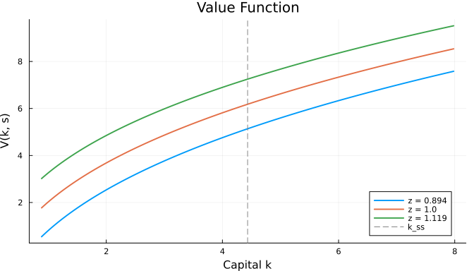

```julia
plot(legend=:bottomright, size=(700, 400))
for s in [1, 4, 7]
    plot!(m.k_grid, sol.V[:, s], linewidth=2,
          label="z = $(round(m.z_grid[s], digits=3))")
end
xlabel!("Capital k")
ylabel!("V(k, s)")
title!("Value Function")
vline!([ss.k], color=:gray, linestyle=:dash, label="k_ss")
```

- Higher productivity $z$ → higher value (more output at every $k$)
- Value is **concave** in $k$ (diminishing returns to capital)

### The Savings Policy $k'(k, s)$

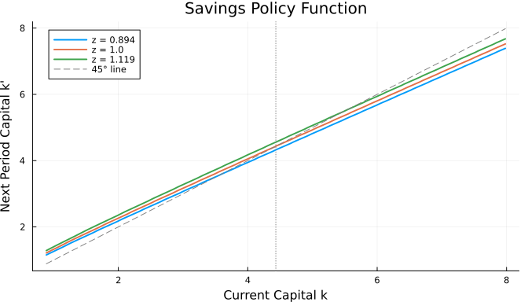

```julia
plot(legend=:topleft, size=(700, 400))
for s in [1, 4, 7]
    plot!(m.k_grid, sol.kp[:, s], linewidth=2,
          label="z = $(round(m.z_grid[s], digits=3))")
end
plot!(m.k_grid, m.k_grid, color=:gray, linestyle=:dash, label="45° line")
xlabel!("Current Capital k")
ylabel!("Next Period Capital k'")
title!("Savings Policy Function")
vline!([ss.k], color=:gray, linestyle=:dot, label="")
```

- **Above the 45° line**: capital is growing ($k' > k$)
- **Below the 45° line**: capital is shrinking ($k' < k$)
- The crossing point is the **steady state** for each $z$

### The Consumption Policy $c(k, s)$

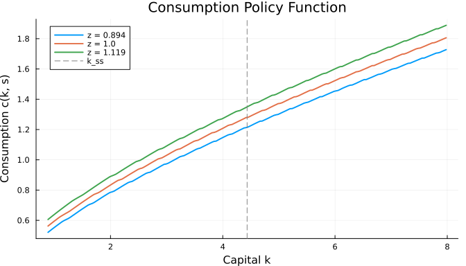

```julia
plot(legend=:topleft, size=(700, 400))
for s in [1, 4, 7]
    plot!(m.k_grid, sol.c[:, s], linewidth=2,
          label="z = $(round(m.z_grid[s], digits=3))")
end
xlabel!("Capital k")
ylabel!("Consumption c(k, s)")
title!("Consumption Policy Function")
vline!([ss.k], color=:gray, linestyle=:dash, label="k_ss")
```

- Consumption is **increasing** in both $k$ and $z$
- High productivity → more output → consume more **and** save more

### The Investment Policy

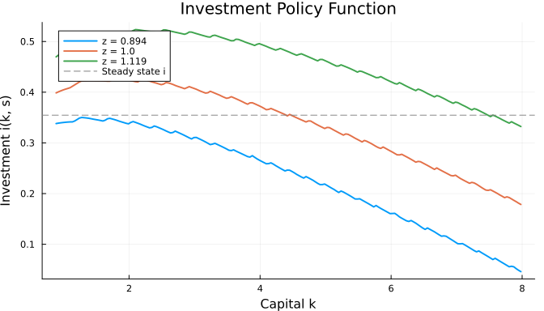

```julia
i_policy = sol.kp .- (1 - m.δ) .* m.k_grid         # i = k' - (1-δ)k

plot(legend=:topleft, size=(700, 400))
for s in [1, 4, 7]
    plot!(m.k_grid, i_policy[:, s], linewidth=2,
          label="z = $(round(m.z_grid[s], digits=3))")
end
xlabel!("Capital k")
ylabel!("Investment i(k, s)")
title!("Investment Policy Function")
hline!([m.δ * ss.k], color=:gray, linestyle=:dash, label="Steady state i")
```

- Investment responds **strongly** to productivity
  - when $z$ is high, the agent invests heavily
- This foreshadows a key business cycle fact: **investment is volatile**

# Simulation

## Simulating the Economy

### The Simulation Function

```julia
function simulateRBC(m::RBCModel, sol, T; seed=42)
    # Initialize at steady state
    # For each period:
        # use policies to get k', c, i
        # draw next period's productivity from the Markov chain
        # update state k_{t+1} = k'
    # Return a DataFrame with columns t, k, z, y, c, i
end
```

### The Simulation Function

```julia
function simulateRBC(m::RBCModel, sol, T; seed=42)
    Random.seed!(seed)
    (; α, δ, z_grid, P_z, N_z) = m
    k_sim = zeros(T); z_sim = zeros(T); s_sim = zeros(Int, T)
    y_sim = zeros(T); c_sim = zeros(T); i_sim = zeros(T)
    k_sim[1] = steady_state(m).k                    # start at steady state
    s_sim[1] = (N_z + 1) ÷ 2                        # start at median z
    for t in 1:T
        s = s_sim[t]
        z = z_grid[s]
        kp = sol.kp_itp[s](k_sim[t])               # interpolated policy!
        z_sim[t] = z
        y_sim[t] = z * k_sim[t]^α
        c_sim[t] = y_sim[t] + (1-δ)*k_sim[t] - kp
        i_sim[t] = kp - (1-δ)*k_sim[t]
        if t < T
            k_sim[t+1] = kp
            s_sim[t+1] = rand(Categorical(P_z[s, :]))
        end
    end
    return DataFrame(t=1:T, k=k_sim, z=z_sim, y=y_sim, c=c_sim, i=i_sim)
end
```

```
simulateRBC (generic function with 1 method)
```

### Using Interpolated Policies

- Since `solveRBC` returns interpolated functions, simulation just **calls** them:

```julia
kp = sol.kp_itp[s](k_sim[t])         # reads like math: k'(k_t, s_t)
```

- The current capital $k_t$ may not be on our grid (because last period’s optimal $k'$ was found by continuous optimization)
- The interpolated policy function evaluates $k'(k_t, s_t)$ at **any** $k_t$

**Interpolation Everywhere**

Linear interpolation is used in **two places**: (1) inside VFI to evaluate the continuation value, and (2) in simulation to evaluate the policy function. Both are essential for handling the continuous state space.

### Running the Simulation

```julia
sim = simulateRBC(m, sol, 200)
first(sim, 6)
```

6×6 DataFrame

| Row | t Int64 | k Float64 | z Float64 | y Float64 | c Float64 | i Float64 |
| --- | --- | --- | --- | --- | --- | --- |
| 1 | 1 | 4.43384 | 1.0 | 1.6347 | 1.27999 | 0.354707 |
| 2 | 2 | 4.43384 | 1.0 | 1.6347 | 1.27999 | 0.354707 |
| 3 | 3 | 4.43384 | 1.0 | 1.6347 | 1.27999 | 0.354707 |
| 4 | 4 | 4.43384 | 1.0 | 1.6347 | 1.27999 | 0.354707 |
| 5 | 5 | 4.43384 | 1.0 | 1.6347 | 1.27999 | 0.354707 |
| 6 | 6 | 4.43384 | 1.0 | 1.6347 | 1.27999 | 0.354707 |

- Each row is one period; columns are the macro aggregates
- DataFrames give us a clean, tabular view of the simulation and powerful tools for computing statistics

### Output, Consumption, and Investment

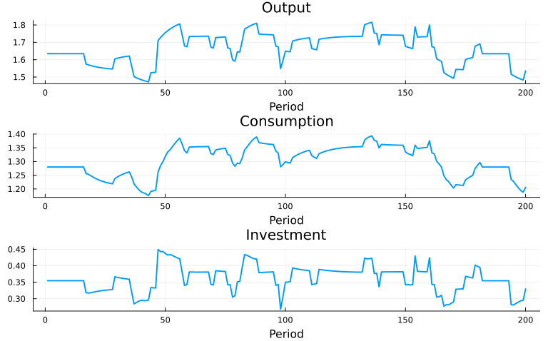

```julia
p1 = plot(sim.y, linewidth=2, label="", title="Output", size=(800, 150))
p2 = plot(sim.c, linewidth=2, label="", title="Consumption", size=(800, 150))
p3 = plot(sim.i, linewidth=2, label="", title="Investment", size=(800, 150))
plot(p1, p2, p3, layout=(3, 1), size=(800, 500), xlabel="Period")
```

- Consumption is **smoother** than output
  - households smooth consumption over time
- Investment is **more volatile** than output
  - the main adjustment margin

### Productivity and Capital

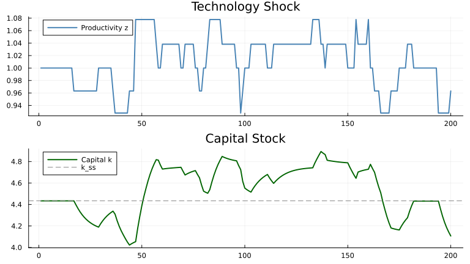

```julia
p1 = plot(sim.z, linewidth=2, color=:steelblue, label="Productivity z",
          title="Technology Shock", size=(800, 200))
p2 = plot(sim.k, linewidth=2, color=:darkgreen, label="Capital k",
          title="Capital Stock", size=(800, 200))
hline!(p2, [ss.k], color=:gray, linestyle=:dash, label="k_ss")
plot(p1, p2, layout=(2,1), size=(800, 450))
```

- Capital responds **sluggishly** to productivity shocks
  - it takes time to build (or deplete) capital
- This is the **propagation mechanism** that turns short-lived shocks into persistent cycles

## Business Cycle Statistics

### Computing Moments

- Simulate a long series and construct **log-deviation** :

```julia
sim_long = simulateRBC(m, sol, 10_000)

sim_long.y_dev = log.(sim_long.y) .- mean(log.(sim_long.y))
sim_long.c_dev = log.(sim_long.c) .- mean(log.(sim_long.c))
sim_long.i_dev = log.(sim_long.i) .- mean(log.(sim_long.i))
sim_long.k_dev = log.(sim_long.k) .- mean(log.(sim_long.k))

first(sim_long, 6) #report the first 6 rows
```

6×10 DataFrame

| Row | t Int64 | k Float64 | z Float64 | y Float64 | c Float64 | i Float64 | y_dev Float64 | c_dev Float64 | i_dev Float64 | k_dev Float64 |
| --- | --- | --- | --- | --- | --- | --- | --- | --- | --- | --- |
| 1 | 1 | 4.43384 | 1.0 | 1.6347 | 1.27999 | 0.354707 | -0.00359466 | -0.00367429 | -0.000783353 | -0.00496687 |
| 2 | 2 | 4.43384 | 1.0 | 1.6347 | 1.27999 | 0.354707 | -0.00359466 | -0.00367429 | -0.000783354 | -0.00496687 |
| 3 | 3 | 4.43384 | 1.0 | 1.6347 | 1.27999 | 0.354707 | -0.00359466 | -0.00367429 | -0.000783355 | -0.00496687 |
| 4 | 4 | 4.43384 | 1.0 | 1.6347 | 1.27999 | 0.354707 | -0.00359466 | -0.00367429 | -0.000783356 | -0.00496688 |
| 5 | 5 | 4.43384 | 1.0 | 1.6347 | 1.27999 | 0.354707 | -0.00359466 | -0.00367429 | -0.000783357 | -0.00496688 |
| 6 | 6 | 4.43384 | 1.0 | 1.6347 | 1.27999 | 0.354707 | -0.00359466 | -0.00367429 | -0.000783359 | -0.00496688 |

### Standard Deviations

```julia
stats = DataFrame(
    Variable   = ["Output", "Consumption", "Investment", "Capital"],
    σ_pct      = [100*std(sim_long.y_dev), 100*std(sim_long.c_dev), 100*std(sim_long.i_dev), 100*std(sim_long.k_dev)],
    σ_relative = [1.0, std(sim_long.c_dev)/std(sim_long.y_dev), std(sim_long.i_dev)/std(sim_long.y_dev), std(sim_long.k_dev)/std(sim_long.y_dev)],
    corr_y     = [1.0, cor(sim_long.y_dev, sim_long.c_dev), cor(sim_long.y_dev, sim_long.i_dev), cor(sim_long.y_dev, sim_long.k_dev)]
)
stats
```

4×4 DataFrame

| Row | Variable String | σ_pct Float64 | σ_relative Float64 | corr_y Float64 |
| --- | --- | --- | --- | --- |
| 1 | Output | 6.15173 | 1.0 | 1.0 |
| 2 | Consumption | 5.29062 | 0.860021 | 0.965192 |
| 3 | Investment | 11.1569 | 1.81362 | 0.892204 |
| 4 | Capital | 6.4229 | 1.04408 | 0.853609 |

## Business Cycle Observations

**Key Business Cycle Facts**

1. **Consumption is less volatile than output** ($\sigma_c / \sigma_y < 1$) — consumption smoothing
2. **Investment is more volatile than output** — investment absorbs the shocks
3. All variables are **procyclical** (positively correlated with output)

**The RBC Achievement**

With just **one source of randomness** (technology shocks), the model generates realistic comovement among macro aggregates. This was revolutionary in the early 1980s.

## Comparative Statics

### Effect of Persistence ($\rho$)

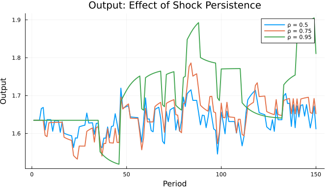

```julia
plot(legend=:topright, size=(700, 400), title="Output: Effect of Shock Persistence")
for ρ_val in [0.5, 0.75, 0.95]
    m_trial = setup!(RBCModel(ρ=ρ_val, N_k=100))
    sol_trial = solveRBC(m_trial, tol=1e-5, verbose=false)
    sim_trial = simulateRBC(m_trial, sol_trial, 150)
    plot!(sim_trial.y, linewidth=2, label="ρ = $ρ_val")
end
xlabel!("Period")
ylabel!("Output")
```

- Higher persistence → longer, more pronounced business cycles
- Low persistence → output fluctuates rapidly but reverts quickly

### Effect of Capital Share ($\alpha$)

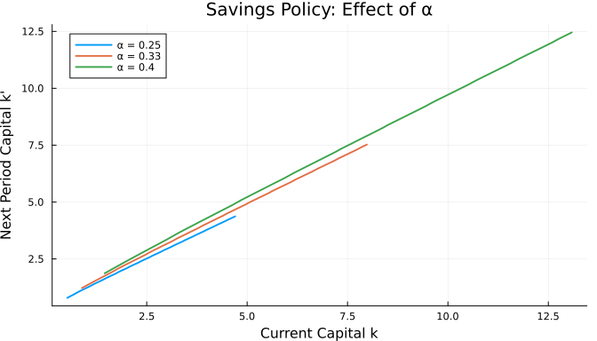

```julia
plot(legend=:topleft, size=(700, 400), title="Savings Policy: Effect of α")
for α_val in [0.25, 0.33, 0.40]
    m_trial = setup!(RBCModel(α=α_val, N_k=100))
    sol_trial = solveRBC(m_trial, tol=1e-5, verbose=false)
    s_mid = (m_trial.N_z + 1) ÷ 2
    plot!(m_trial.k_grid, sol_trial.kp[:, s_mid], linewidth=2, label="α = $α_val")
end
xlabel!("Current Capital k")
ylabel!("Next Period Capital k'")
```

- Higher $\alpha$ → capital is more productive → agent saves more → higher steady-state capital

### Effect of Discount Factor ($\beta$)

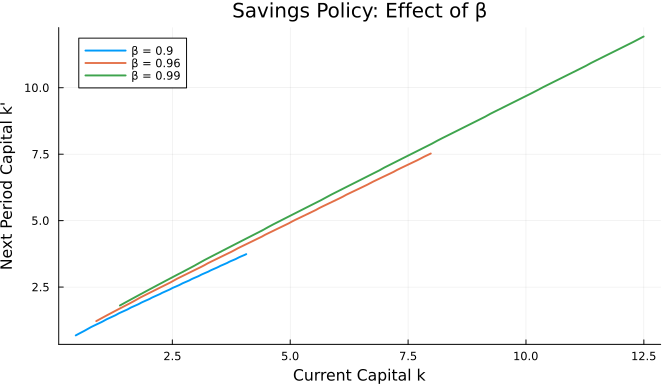

```julia
plot(legend=:topleft, size=(700, 400), title="Savings Policy: Effect of β")
for β_val in [0.90, 0.96, 0.99]
    m_trial = setup!(RBCModel(β=β_val, N_k=100))
    sol_trial = solveRBC(m_trial, tol=1e-5, verbose=false)
    s_mid = (m_trial.N_z + 1) ÷ 2
    plot!(m_trial.k_grid, sol_trial.kp[:, s_mid], linewidth=2, label="β = $β_val")
end
xlabel!("Current Capital k")
ylabel!("Next Period Capital k'")
```

- More **patient** agents ($\beta$ closer to 1) save more → higher steady-state capital
- Impatient agents consume more today, accumulate less capital

# Linearized Solution

## The Euler Equation

### Notation

- Define **deviations from steady state**:

$$\hat{k}_t \equiv k_t - k_{ss}, \qquad \hat{c}_t \equiv c_t - c_{ss}, \qquad \hat{z}_t \equiv z_t - 1$$

- We’ll linearize by taking a **first-order Taylor expansion** around the steady state, dropping terms like $\hat{k}_t \cdot \hat{z}_t$ (second-order small)

**Why Linearize?**

VFI is accurate but **slow** ($N_k \times N_z$ optimization problems per iteration). Linearization gives a policy rule that’s nearly exact near the steady state — and almost instant to compute.

## Linearizing the Resource Constraint

### The Resource Constraint

- Recall the aggregate resource constraint:

$$c_t + k_{t+1} = z_t \, k_t^\alpha + (1-\delta) \, k_t$$

- Write each variable as steady state + deviation:

$$(c_{ss} + \hat{c}_t) + (k_{ss} + \hat{k}_{t+1}) = (1 + \hat{z}_t)(k_{ss} + \hat{k}_t)^\alpha + (1-\delta)(k_{ss} + \hat{k}_t)$$

### Differentiating the Resource Constraint

- First-order approximation of $(k_{ss} + \hat{k}_t)^\alpha$:

$$(k_{ss} + \hat{k}_t)^\alpha \approx k_{ss}^\alpha + \alpha \, k_{ss}^{\alpha-1} \, \hat{k}_t$$

- Expanding the right side (dropping $\hat{z}_t \cdot \hat{k}_t$):

$$\text{RHS} \approx k_{ss}^\alpha + \underbrace{\alpha k_{ss}^{\alpha-1}}_{r_{ss}} \hat{k}_t + \underbrace{k_{ss}^\alpha}_{y_{ss}} \hat{z}_t + (1-\delta) k_{ss} + (1-\delta) \hat{k}_t$$

### Linearized Resource Constraint

- Subtracting the steady-state equation ($c_{ss} + k_{ss} = y_{ss} + (1-\delta) k_{ss}$), the constant terms cancel:

$$\hat{c}_t + \hat{k}_{t+1} = \underbrace{(r_{ss} + 1 - \delta)}_{= 1/\beta} \hat{k}_t + y_{ss} \, \hat{z}_t$$

$$\boxed{\hat{c}_t = \frac{1}{\beta} \, \hat{k}_t - \hat{k}_{t+1} + y_{ss} \, \hat{z}_t}$$

- This tells us $\hat{c}_t$ as a **linear function** of $\hat{k}_t$, $\hat{k}_{t+1}$, and $\hat{z}_t$
- Used $r_{ss} + 1 - \delta = 1/\beta$ (the steady-state Euler equation)

## Linearizing the Euler Equation

### First-Order Condition

- Taking the FOC of the Bellman equation with respect to $k'$:

$$\frac{1}{c_t} = \beta \, \mathbb{E}_t \left[ \frac{\alpha z_{t+1} k_{t+1}^{\alpha-1} + 1 - \delta}{c_{t+1}} \right]$$

- **Left side**: marginal cost of saving one more unit (foregone consumption today)
- **Right side**: marginal benefit (discounted expected return, valued in consumption units)

**The Euler Equation**

At the optimum, the household is **indifferent** between consuming one more unit today vs. saving it and consuming the return tomorrow.

### Differentiating the Euler Equation

- The Euler equation is $\displaystyle \frac{1}{c_t} = \beta \, \mathbb{E}_t \left[ \frac{R_{t+1}}{c_{t+1}} \right]$ where $R_{t+1} = \alpha z_{t+1} k_{t+1}^{\alpha-1} + 1 - \delta$
- Linearize **left side**: $\;\displaystyle \frac{1}{c_{ss} + \hat{c}_t} \approx \frac{1}{c_{ss}} - \frac{\hat{c}_t}{c_{ss}^2}$
- Linearize **right side**: expand $R_{t+1}/c_{t+1}$ around steady state

$$\frac{R_{ss} + \hat{R}_{t+1}}{c_{ss} + \hat{c}_{t+1}} \approx \frac{R_{ss}}{c_{ss}} + \frac{\hat{R}_{t+1}}{c_{ss}} - \frac{R_{ss} \, \hat{c}_{t+1}}{c_{ss}^2}$$

### Linearized Return

- The deviation of the gross return is:

$$\hat{R}_{t+1} = \underbrace{\frac{(\alpha - 1) \, r_{ss}}{k_{ss}}}_{\text{diminishing MPK}} \hat{k}_{t+1} + \underbrace{r_{ss}}_{\text{productivity effect}} \hat{z}_{t+1}$$

- More capital $\rightarrow$ **lower** return (diminishing returns, since $\alpha - 1 < 0$)
- Higher productivity $\rightarrow$ **higher** return

### Linearized Euler Equation

- Setting LHS = $\beta \cdot$ RHS and using $\beta R_{ss} = 1$ to cancel constant terms:

$$-\frac{\hat{c}_t}{c_{ss}^2} = \frac{\beta}{c_{ss}} \mathbb{E}_t[\hat{R}_{t+1}] - \frac{1}{c_{ss}^2} \mathbb{E}_t[\hat{c}_{t+1}]$$

- Multiply by $-c_{ss}^2$:

$$\boxed{\hat{c}_t = \mathbb{E}_t[\hat{c}_{t+1}] - \beta \, c_{ss} \, \mathbb{E}_t[\hat{R}_{t+1}]}$$

- This is an **intertemporal substitution** equation: when expected returns are high ($\hat{R}_{t+1} > 0$), the household **saves more** today ($\hat{c}_t < \mathbb{E}_t[\hat{c}_{t+1}]$)

## Solving the Linearized System

### Consumption Is Linear in $\hat{k}_t$ and $\hat{z}_t$

- **Guess** a linear policy rule: $\;\hat{k}_{t+1} = \phi_k \, \hat{k}_t + \phi_z \, \hat{z}_t$
- Substitute into the linearized resource constraint $\hat{c}_t = \tfrac{1}{\beta}\hat{k}_t - \hat{k}_{t+1} + y_{ss}\hat{z}_t$:

$$\hat{c}_t = \underbrace{\left(\tfrac{1}{\beta} - \phi_k\right)}_{\equiv\; \psi_k} \hat{k}_t + \underbrace{(y_{ss} - \phi_z)}_{\equiv\; \psi_z} \hat{z}_t$$

$$\boxed{\hat{c}_t = \psi_k \, \hat{k}_t + \psi_z \, \hat{z}_t}$$

- Once we know $(\phi_k, \phi_z)$, consumption is **pinned down** by the resource constraint

### Expected Future Consumption and Return

- Using $\mathbb{E}_t[\hat{z}_{t+1}] = \rho \, \hat{z}_t$ and $\hat{k}_{t+1} = \phi_k \hat{k}_t + \phi_z \hat{z}_t$:

$$\mathbb{E}_t[\hat{c}_{t+1}] = \psi_k \underbrace{(\phi_k \hat{k}_t + \phi_z \hat{z}_t)}_{\hat{k}_{t+1}} + \psi_z \underbrace{\rho \, \hat{z}_t}_{\mathbb{E}_t[\hat{z}_{t+1}]}$$

- Define $\gamma \equiv \tfrac{(\alpha-1)\,r_{ss}}{k_{ss}}$ (the curvature of the MPK). Then:

$$\mathbb{E}_t[\hat{R}_{t+1}] = \gamma \underbrace{(\phi_k \hat{k}_t + \phi_z \hat{z}_t)}_{\hat{k}_{t+1}} + r_{ss} \underbrace{\rho \, \hat{z}_t}_{\mathbb{E}_t[\hat{z}_{t+1}]}$$

- Both expectations are **linear** in $(\hat{k}_t, \hat{z}_t)$ — so matching coefficients will pin down $\phi$

### Finding $\phi_k$: Match Coefficients on $\hat{k}_t$

- Plug into the Euler equation $\hat{c}_t = \mathbb{E}_t[\hat{c}_{t+1}] - \beta c_{ss}\,\mathbb{E}_t[\hat{R}_{t+1}]$ and collect terms on $\hat{k}_t$:

$$\psi_k = \phi_k\bigl(\psi_k - \beta\, c_{ss}\, \gamma\bigr)$$

- Since $\psi_k = \tfrac{1}{\beta} - \phi_k$, this is **one equation in one unknown** ($\phi_k$):

$$\boxed{\frac{1}{\beta} - \phi_k = \phi_k\!\left(\frac{1}{\beta} - \phi_k - \beta \, c_{ss}\, \gamma\right)}$$

- This is a **quadratic** in $\phi_k$ — pick the stable root ($|\phi_k| < 1$)

### Finding $\phi_z$: Match Coefficients on $\hat{z}_t$

- Once $\phi_k$ is known ($\Rightarrow$ $\psi_k$ is known), collect terms on $\hat{z}_t$:

$$\psi_z = \psi_k \phi_z + \psi_z \rho - \beta\, c_{ss}\bigl(\gamma \phi_z + r_{ss}\,\rho\bigr)$$

- Substitute $\psi_z = y_{ss} - \phi_z$ and collect $\phi_z$ terms:

$$\boxed{\phi_z = \frac{y_{ss}(1 - \rho) + \beta\, c_{ss}\, r_{ss}\, \rho}{\psi_k - \beta\, c_{ss}\, \gamma + (1 - \rho)}}$$

- This is a **linear** equation — just arithmetic once $\phi_k$ is known

### Finding $\phi_z$: Match Coefficients on $\hat{z}_t$

**Summary of the Approach**

1. Guess $\hat{k}_{t+1} = \phi_k \hat{k}_t + \phi_z \hat{z}_t$ → consumption $\hat{c}_t = \psi_k \hat{k}_t + \psi_z \hat{z}_t$ follows from the RC
2. Compute $\mathbb{E}_t[\hat{c}_{t+1}]$ and $\mathbb{E}_t[\hat{R}_{t+1}]$ as linear functions of $(\hat{k}_t, \hat{z}_t)$
3. Match $\hat{k}_t$ coefficients in the Euler equation → **quadratic** for $\phi_k$
4. Match $\hat{z}_t$ coefficients → **linear** equation for $\phi_z$

## Julia Implementation

### Solving for $\phi_k$

- Use `NonlinearSolve.jl` to solve the $\phi_k$ equation, then compute $\phi_z$ directly:

```julia
using NonlinearSolve
```

```julia
function linearize_rbc(m)
    (; α, β, δ, ρ) = m
    ss_vals = steady_state(m)
    k_ss = ss_vals.k;  y_ss = ss_vals.y;  c_ss = ss_vals.c
    r_ss = α * k_ss^(α-1)
    γ = (α - 1) * r_ss / k_ss                        # curvature of MPK

    # Step 1: solve for ϕ_k  (ψ_k = ψ_k·ϕ_k − β·c_ss·γ·ϕ_k)
    function ϕk_residual(x, p)
        ψ_k = 1/β - x[1]
        return [ψ_k - x[1] * (ψ_k - β * c_ss * γ)]
    end
    prob = NonlinearProblem(ϕk_residual, [0.9])
    ϕ_k = solve(prob, NewtonRaphson()).u[1]

    # Step 2: compute ϕ_z directly
    ψ_k = 1/β - ϕ_k
    ϕ_z = (y_ss*(1 - ρ) + β*c_ss*r_ss*ρ) / (ψ_k - β*c_ss*γ + (1 - ρ))

    return (ϕ_k=ϕ_k, ϕ_z=ϕ_z)
end
```

```
linearize_rbc (generic function with 1 method)
```

### The Linearized Policy Rule

```julia
lin = linearize_rbc(m)
println("ϕ_k = $(round(lin.ϕ_k, digits=4))")
println("ϕ_z = $(round(lin.ϕ_z, digits=4))")
```

```
ϕ_k = 0.8784
ϕ_z = 1.0427
```

- The linearized capital policy:

$$k_{t+1} \approx k_{ss} + \phi_k \, (k_t - k_{ss}) + \phi_z \, (z_t - 1)$$

- $|\phi_k| < 1$: capital **mean-reverts** toward the steady state
- $\phi_z > 0$: higher productivity $\rightarrow$ **save more**

## Comparing to VFI

### Policy Functions

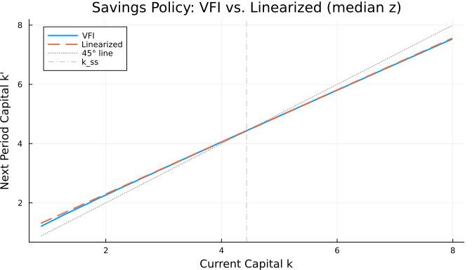

```julia
s_mid = (m.N_z + 1) ÷ 2
kp_linear = ss.k .+ lin.ϕ_k .* (m.k_grid .- ss.k) .+ lin.ϕ_z .* (m.z_grid[s_mid] - 1.0)

plot(m.k_grid, sol.kp[:, s_mid], linewidth=2, label="VFI",
     legend=:topleft, size=(700, 400))
plot!(m.k_grid, kp_linear, linewidth=2, linestyle=:dash, label="Linearized")
plot!(m.k_grid, m.k_grid, color=:gray, linestyle=:dot, label="45° line")
vline!([ss.k], color=:gray, linestyle=:dashdot, label="k_ss", alpha=0.5)
xlabel!("Current Capital k")
ylabel!("Next Period Capital k'")
title!("Savings Policy: VFI vs. Linearized (median z)")
```

- Near $k_{ss}$: the two solutions **nearly coincide**
- Far from $k_{ss}$: the linearized solution diverges — it can’t capture curvature

### Policy Functions Across Productivity Levels

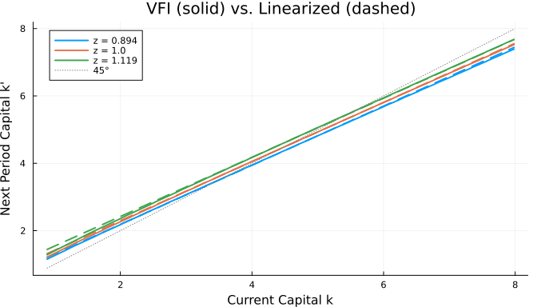

```julia
plot(legend=:topleft, size=(700, 400), title="VFI (solid) vs. Linearized (dashed)")
for s in [1, 4, 7]
    z = m.z_grid[s]
    kp_lin = ss.k .+ lin.ϕ_k .* (m.k_grid .- ss.k) .+ lin.ϕ_z .* (z - 1.0)
    plot!(m.k_grid, sol.kp[:, s], linewidth=2,
          label="z = $(round(z, digits=3))", color=palette(:default)[s ÷ 3 + 1])
    plot!(m.k_grid, kp_lin, linewidth=2, linestyle=:dash,
          label="", color=palette(:default)[s ÷ 3 + 1])
end
plot!(m.k_grid, m.k_grid, color=:gray, linestyle=:dot, label="45°")
xlabel!("Current Capital k")
ylabel!("Next Period Capital k'")
```

### Simulating the Linearized Model

```julia
function simulateRBC_linear(m, lin, T; seed=42)
    Random.seed!(seed)
    (; α, δ, z_grid, P_z, N_z) = m
    k_ss = steady_state(m).k
    k_sim = zeros(T);  s_sim = zeros(Int, T)
    y_sim = zeros(T);  c_sim = zeros(T);  i_sim = zeros(T)
    k_sim[1] = k_ss
    s_sim[1] = (N_z + 1) ÷ 2
    for t in 1:T
        z = z_grid[s_sim[t]]
        kp = k_ss + lin.ϕ_k * (k_sim[t] - k_ss) + lin.ϕ_z * (z - 1.0)
        y_sim[t] = z * k_sim[t]^α
        c_sim[t] = y_sim[t] + (1-δ)*k_sim[t] - kp
        i_sim[t] = kp - (1-δ)*k_sim[t]
        if t < T
            k_sim[t+1] = kp
            s_sim[t+1] = rand(Categorical(P_z[s_sim[t], :]))
        end
    end
    return DataFrame(t=1:T, k=k_sim, z=z_grid[s_sim], y=y_sim, c=c_sim, i=i_sim)
end
```

```
simulateRBC_linear (generic function with 1 method)
```

### Comparing Simulated Output

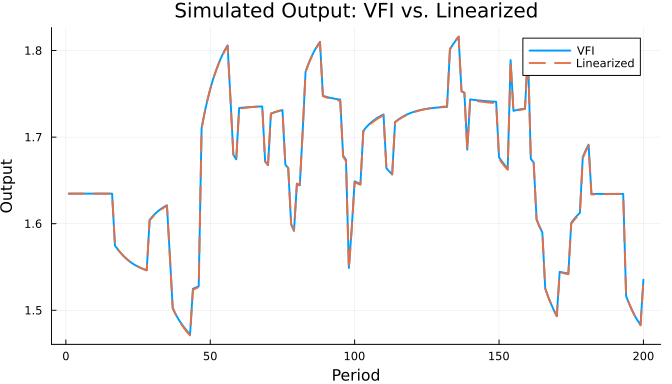

```julia
sim_vfi = simulateRBC(m, sol, 200)
sim_lin = simulateRBC_linear(m, lin, 200)

plot(sim_vfi.y, linewidth=2, label="VFI", legend=:topright, size=(700, 400))
plot!(sim_lin.y, linewidth=2, linestyle=:dash, label="Linearized")
xlabel!("Period")
ylabel!("Output")
title!("Simulated Output: VFI vs. Linearized")
```

- The two simulations track each other **very closely**
- Near the steady state, linearization is an excellent approximation

### Comparing Simulated Consumption and Investment

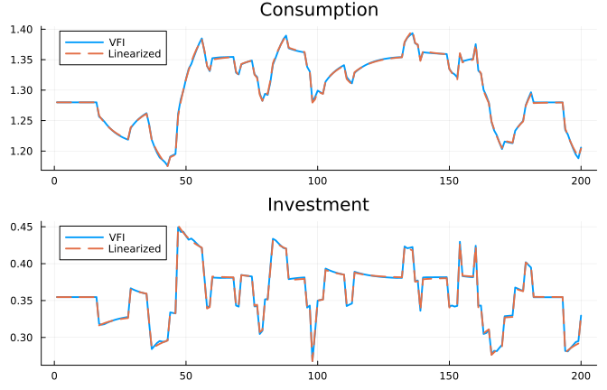

```julia
p1 = plot(sim_vfi.c, linewidth=2, label="VFI", title="Consumption", size=(700, 200))
plot!(p1, sim_lin.c, linewidth=2, linestyle=:dash, label="Linearized")
p2 = plot(sim_vfi.i, linewidth=2, label="VFI", title="Investment", size=(700, 200))
plot!(p2, sim_lin.i, linewidth=2, linestyle=:dash, label="Linearized")
plot(p1, p2, layout=(2,1), size=(700, 450))
```

**Linearization: Pros and Cons**

**Pros**: Almost instant to compute, gives closed-form policy rules, easy to analyze theoretically.

**Cons**: Only accurate near the steady state, misses nonlinearities (e.g., precautionary savings, occasionally binding constraints).

Most of the macro literature uses linearization (or higher-order perturbation). VFI is the gold standard for accuracy but is computationally demanding.

# Summary

### Key Takeaways

**Concepts**

- Real Business Cycle theory
- Calibration: matching long-run moments and the Solow residual
- Stochastic neoclassical growth model
- Social planner’s Bellman equation
- Linear interpolation for continuous states
- Rouwenhorst discretization of AR(1) processes
- Business cycle statistics: volatilities, correlations
- Linearization via method of undetermined coefficients and root solving

**Julia Tools**

- `Interpolations.jl`: `linear_interpolation` with call syntax
- `Optim.jl`: `Brent()` for 1D optimization
- `NonlinearSolve.jl`: `NonlinearProblem`, `NewtonRaphson()`
- `DataFrames.jl`: tabular simulation output
- Mutable structs with `setup!` and `(; ...) = m` destructuring
- `Categorical` for Markov simulation
- Broadcasting for element-wise operations